# Formative Exercise 06: MSc Data Skills Course

Psychology, University of Glasgow

Edit the code chunks below and knit the document. You can pipe your objects to `glimpse()` or `print()` to display them.

## Mutating joins

### Question 1A

Load the following data from the dataskills package (or access the linked CSV files online). Each participant is identified by a unique `user_id`.

- [`disgust_scores`](https://psyteachr.github.io/msc-data-skills/data/disgust_scores.csv)
- [`personality_scores`](https://psyteachr.github.io/msc-data-skills/data/personality_scores.csv)
- [`users`](https://psyteachr.github.io/msc-data-skills/data/users.csv)

```r
data("disgust_scores", package = "dataskills")
data("personality_scores", package = "dataskills")
data("users", package = "dataskills")
```

### Question 1B

Add participant data to the disgust_scores table.

```r
study1 <- left_join(disgust_scores, users, by = "user_id") %>%
  glimpse()
```

```
## Rows: 20,000
## Columns: 8
## $ id        <dbl> 1, 3, 4, 5, 6, 7, 8, 9, 10, 11, 12, 13, 14, 15, 16, …
## $ user_id   <dbl> 1, 155324, 155366, 155370, 155386, 155409, 155427, 1…
## $ date      <date> 2008-07-10, 2008-07-11, 2008-07-12, 2008-07-12, 200…
## $ moral     <dbl> 1.428571, 3.000000, 5.571429, 5.714286, 1.428571, 4.…
## $ pathogen  <dbl> 2.714286, 2.571429, 4.000000, 4.857143, 3.857143, 4.…
## $ sexual    <dbl> 1.7142857, 1.8571429, 0.4285714, 4.7142857, 3.714285…
## $ sex       <chr> "female", "female", "male", "female", "male", "male"…
## $ birthyear <dbl> 1976, 1984, 1982, 1968, 1983, 1983, 1987, 1978, 1986…
```

### Question 1C

Calculate the approximate age of each participant on the date they did the disgust_scores questionnaire and put this in a column called `age_years` in a new table called `study1_ages`.

```r
study1_ages <- study1 %>%
  mutate(
    age_years = year(date) - birthyear
  ) %>%
  glimpse()
```

```
## Rows: 20,000
## Columns: 9
## $ id        <dbl> 1, 3, 4, 5, 6, 7, 8, 9, 10, 11, 12, 13, 14, 15, 16, …
## $ user_id   <dbl> 1, 155324, 155366, 155370, 155386, 155409, 155427, 1…
## $ date      <date> 2008-07-10, 2008-07-11, 2008-07-12, 2008-07-12, 200…
## $ moral     <dbl> 1.428571, 3.000000, 5.571429, 5.714286, 1.428571, 4.…
## $ pathogen  <dbl> 2.714286, 2.571429, 4.000000, 4.857143, 3.857143, 4.…
## $ sexual    <dbl> 1.7142857, 1.8571429, 0.4285714, 4.7142857, 3.714285…
## $ sex       <chr> "female", "female", "male", "female", "male", "male"…
## $ birthyear <dbl> 1976, 1984, 1982, 1968, 1983, 1983, 1987, 1978, 1986…
## $ age_years <dbl> 32, 24, 26, 40, 25, 25, 21, 30, 22, 38, 22, 23, 42, …
```

### Question 2A

Add the participant data to the disgust_scores data, but have the columns from the participant table first.

```r
study2 <- right_join(users, disgust_scores, by = "user_id") %>%
  glimpse()
```

```
## Rows: 20,000
## Columns: 8
## $ user_id   <dbl> 0, 1, 2, 2118, 2311, 3630, 4458, 4651, 4976, 5469, 6…
## $ sex       <chr> NA, "female", "male", "female", "male", "male", "fem…
## $ birthyear <dbl> NA, 1976, 1985, 1985, 1982, 1968, 1933, 1979, 1981, …
## $ id        <dbl> 1199, 1, 1599, 13332, 23, 1160, 7980, 552, 37829, 69…
## $ date      <date> 2008-10-07, 2008-07-10, 2008-10-27, 2012-01-02, 200…
## $ moral     <dbl> 5.2857143, 1.4285714, NA, 1.0000000, 4.0000000, NA, …
## $ pathogen  <dbl> 4.714286, 2.714286, NA, 5.000000, 4.285714, 2.142857…
## $ sexual    <dbl> 2.1428571, 1.7142857, NA, 3.0000000, 1.8571429, 1.14…
```

### Question 2B

How many times was the disgust_scores questionnaire completed by each sex? Create a table called `study2_by_sex` that has two columns: `sex` and `n`.

```r
study2_by_sex <- study2 %>%
  count(sex) %>%
  print()
```

```
## # A tibble: 4 x 2
##   sex           n
##   <chr>     <int>
## 1 female    13886
## 2 male       6012
## 3 nonbinary     3
## 4 <NA>         99
```

### Question 2C

*Advanced*: Make a graph of how many people completed the questionnaire each year.

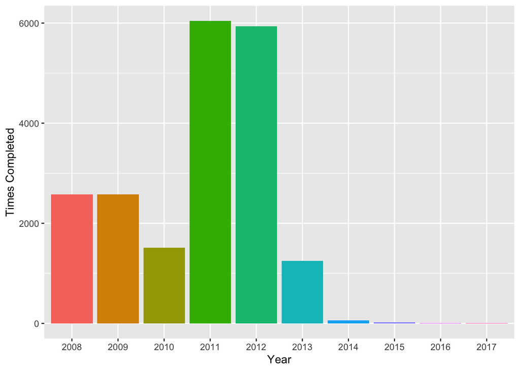

```r
study2 %>%
  mutate(year = substr(date, 1, 4)) %>%
  count(year) %>%
  ggplot() +
  geom_col(aes(year, n, fill = year)) +
  labs(
    x = "Year",
    y = "Times Completed"
  ) +
  guides(fill = FALSE)
```

### Question 3A

Create a table with only disgust_scores and personality_scores data from the same `user_id` collected on the same `date`.

```r
study3 <- inner_join(disgust_scores, personality_scores,
                     by = c("user_id", "date")) %>%
  glimpse()
```

```
## Rows: 555
## Columns: 11
## $ id       <dbl> 3, 6, 17, 18, 21, 22, 24, 25, 32, 33, 34, 37, 39, 43,…
## $ user_id  <dbl> 155324, 155386, 155567, 155571, 155665, 155682, 15571…
## $ date     <date> 2008-07-11, 2008-07-12, 2008-07-14, 2008-07-14, 2008…
## $ moral    <dbl> 3.000000, 1.428571, 5.571429, 2.714286, 4.142857, 2.7…
## $ pathogen <dbl> 2.571429, 3.857143, 4.714286, 6.000000, 4.142857, 3.0…
## $ sexual   <dbl> 1.8571429, 3.7142857, 2.5714286, 4.4285714, 3.4285714…
## $ Ag       <dbl> 4.000000, 3.142857, 5.285714, 3.714286, 2.857143, 3.4…
## $ Co       <dbl> 3.300000, 2.600000, 5.700000, 3.800000, 1.800000, 3.0…
## $ Ex       <dbl> 4.8888889, 4.0000000, 3.8888889, 4.5555556, 4.6666667…
## $ Ne       <dbl> 2.375000, 0.250000, 1.125000, 2.250000, 3.125000, 1.3…
## $ Op       <dbl> 4.714286, 5.142857, 3.142857, 2.857143, 4.571429, 4.8…
```

### Question 3B

Join data from the same `user_id`, regardless of `date`. Does this give you the same data table as above?

```r
study3_nodate <- inner_join(disgust_scores, personality_scores,
                            by = c("user_id")) %>%
  glimpse()
```

```
## Rows: 677
## Columns: 12
## $ id       <dbl> 1, 3, 6, 17, 18, 20, 21, 22, 24, 25, 32, 33, 34, 35, …
## $ user_id  <dbl> 1, 155324, 155386, 155567, 155571, 124756, 155665, 15…
## $ date.x   <date> 2008-07-10, 2008-07-11, 2008-07-12, 2008-07-14, 2008…
## $ moral    <dbl> 1.428571, 3.000000, 1.428571, 5.571429, 2.714286, 5.4…
## $ pathogen <dbl> 2.714286, 2.571429, 3.857143, 4.714286, 6.000000, 5.1…
## $ sexual   <dbl> 1.7142857, 1.8571429, 3.7142857, 2.5714286, 4.4285714…
## $ date.y   <date> 2006-02-08, 2008-07-11, 2008-07-12, 2008-07-14, 2008…
## $ Ag       <dbl> 2.571429, 4.000000, 3.142857, 5.285714, 3.714286, 4.8…
## $ Co       <dbl> 3.000000, 3.300000, 2.600000, 5.700000, 3.800000, 3.8…
## $ Ex       <dbl> 2.6666667, 4.8888889, 4.0000000, 3.8888889, 4.5555556…
## $ Ne       <dbl> 2.250, 2.375, 0.250, 1.125, 2.250, 3.375, 3.125, 1.37…
## $ Op       <dbl> 4.285714, 4.714286, 5.142857, 3.142857, 2.857143, 5.2…
```

### Question 4

Create a table of the disgust_scores and personality_scores data with each `user_id:date` on a single row, containing *all* of the data from both tables.

```r
study4 <- full_join(disgust_scores, personality_scores,
                    by = c("user_id", "date")) %>%
  glimpse()
```

```
## Rows: 34,445
## Columns: 11
## $ id       <dbl> 1, 3, 4, 5, 6, 7, 8, 9, 10, 11, 12, 13, 14, 15, 16, 1…
## $ user_id  <dbl> 1, 155324, 155366, 155370, 155386, 155409, 155427, 15…
## $ date     <date> 2008-07-10, 2008-07-11, 2008-07-12, 2008-07-12, 2008…
## $ moral    <dbl> 1.428571, 3.000000, 5.571429, 5.714286, 1.428571, 4.1…
## $ pathogen <dbl> 2.714286, 2.571429, 4.000000, 4.857143, 3.857143, 4.1…
## $ sexual   <dbl> 1.7142857, 1.8571429, 0.4285714, 4.7142857, 3.7142857…
## $ Ag       <dbl> NA, 4.000000, NA, NA, 3.142857, NA, NA, NA, NA, NA, N…
## $ Co       <dbl> NA, 3.3, NA, NA, 2.6, NA, NA, NA, NA, NA, NA, NA, NA,…
## $ Ex       <dbl> NA, 4.888889, NA, NA, 4.000000, NA, NA, NA, NA, NA, N…
## $ Ne       <dbl> NA, 2.375, NA, NA, 0.250, NA, NA, NA, NA, NA, NA, NA,…
## $ Op       <dbl> NA, 4.714286, NA, NA, 5.142857, NA, NA, NA, NA, NA, N…
```

## Filtering joins

### Question 5

Create a table of just the data from the disgust_scores table for users who completed the personality_scores questionnaire that same day.

```r
study5 <- semi_join(disgust_scores, personality_scores,
                    by = c("user_id", "date")) %>%
  glimpse()
```

```
## Rows: 555
## Columns: 6
## $ id       <dbl> 3, 6, 17, 18, 21, 22, 24, 25, 32, 33, 34, 37, 39, 43,…
## $ user_id  <dbl> 155324, 155386, 155567, 155571, 155665, 155682, 15571…
## $ date     <date> 2008-07-11, 2008-07-12, 2008-07-14, 2008-07-14, 2008…
## $ moral    <dbl> 3.000000, 1.428571, 5.571429, 2.714286, 4.142857, 2.7…
## $ pathogen <dbl> 2.571429, 3.857143, 4.714286, 6.000000, 4.142857, 3.0…
## $ sexual   <dbl> 1.8571429, 3.7142857, 2.5714286, 4.4285714, 3.4285714…
```

### Question 6

Create a table of data from users who did not complete either the personality_scores questionnaire or the disgust_scores questionnaire. (*Hint: this will require two steps; use pipes.*)

```r
study6 <- users %>%
  anti_join(personality_scores, by = "user_id") %>%
  anti_join(disgust_scores, by = "user_id") %>%
  glimpse()
```

```
## Rows: 17,728
## Columns: 3
## $ user_id   <dbl> 9, 10, 17, 19, 20, 21, 22, 23, 24, 27, 30, 31, 32, 3…
## $ sex       <chr> "male", "female", "female", "female", "male", "male"…
## $ birthyear <dbl> 1972, 1978, 1981, 1980, 1964, 1945, 1973, 1985, 1982…
```

## Binding and sets

### Question 7

Load new user data from [dataskills::users2](https://psyteachr.github.io/msc-data-skills/data/users2.csv). Bind them into a single table called `users_all`.

```r
data("users2", package = "dataskills")
users_all <- bind_rows(users, users2) %>%
  glimpse()
```

```
## Rows: 112,043
## Columns: 3
## $ user_id   <dbl> 0, 1, 2, 5, 8, 9, 10, 17, 19, 20, 21, 22, 23, 24, 27…
## $ sex       <chr> NA, "female", "male", "male", "male", "male", "femal…
## $ birthyear <dbl> NA, 1976, 1985, 1980, 1968, 1972, 1978, 1981, 1980, …
```

### Question 8

How many users are in both the first and second user table?

```r
both_n <- dplyr::intersect(users, users2) %>% nrow() %>% print()
```

```
## [1] 11602
```

### Question 9

How many unique users are there in total across the first and second user tables?

```r
unique_users <- dplyr::union(users, users2) %>% nrow() %>% print()
```

```
## [1] 100441
```

### Question 10

How many users are in the first, but not the second, user table?

```r
first_users <- dplyr::setdiff(users, users2) %>% nrow() %>% print()
```

```
## [1] 40441
```

### Question 11

How many users are in the second, but not the first, user table?

```r
second_users <- dplyr::setdiff(users2, users) %>% nrow() %>% print()
```

```
## [1] 48398
```